# Version comparison: v7 vs v8

- Show All Code
- Hide All Code
- View Source

Program-Area / Planning-Area scores. Parameterized report — overall composite and every component score, two releases side by side

Published

2026-11-12

> **Not a pipeline stage** — a standalone, parameterized *report* (no `msens:` target block, so `tar_make()` never runs it). Render it on demand for any two release versions whose `sdm.duckdb` are on disk. The reusable comparison **core lives in `msens`** (`zone_scored_flds`, `zone_scores`, `zone_crosswalk`, `zone_score_delta`, `score_delta`, `score_delta_summary`, `assert_within_tolerance`) so this notebook only *orchestrates* — the math is unit-tested in `msens/tests/testthat/test-validate.R` and can’t drift from what’s reported here.

> ```r
> # render ONE pair, with the versions in the output filename (see scripts/render_compare.R):
> source("scripts/render_compare.R"); render_compare("v6", "v9")   # -> _output/compare_versions_v6_vs_v9.html
> # or from the shell:
> Rscript scripts/render_compare.R v6 v9
> # render every registered pair (data/compare_pairs.csv) that is missing, then rebuild the archive index:
> Rscript scripts/render_compare_sequence.R            # add --redo to re-render them all, or name pairs: v10:v11
> ```

> A bare `quarto render compare_versions.qmd` **stops**: its output would be the unversioned `compare_versions.html`, which is the **archive index** of every rendered pair (`scripts/build_compare_index.R`), and a report there is overwritten by the next version bump. The release lineage the archive follows (v7 → v8 → v10 → v11, and the v7 patches) is `data/compare_pairs.csv`.

> **What is compared.** Scores on each release’s **principal reporting unit** — the 20 BOEM **Program Areas** (v2 onward) or, for a release that scored none, the 36 **Planning Areas** (v1). Ecoregions and subregions are deliberately not reported here. When the two releases used different units, zones are compared **only where they are the same polygon** (`msens::zone_crosswalk()`, intersection over union ≥ 0.999, computed from the polygons at render time); everything else — a Program Area that is a *subset* of a Planning Area, a Planning Area with no Program Area — is listed **adjacent, not compared**, exactly as components present in only one release (v6’s `other`, v8+’s `primary_producer`) are. The overall composite and each **component** it averages (`extrisk_{category}_ecoregion_rescaled` + `primprod_ecoregion_rescaled`) are shown. `Δ = B − A`.

## 1 Setup

```r
librarian::shelf(DBI, duckdb, dplyr, DT, ggplot2, glue, htmltools, knitr, leaflet, purrr,
                 rmapshaper, scales, sf, tidyr, MarineSensitivity/msens, quiet = TRUE)
source(here::here("libs/paths.R"))

va <- params$version_a
vb <- params$version_b
mk <- params$metric_key
stopifnot(va != vb)

# the output must name its two versions: scripts/render_compare.R sets MSENS_COMPARE_OUT to the
# versioned filename before rendering; an unversioned render would overwrite the archive index
out_expected <- glue("compare_versions_{va}_vs_{vb}.html")
if (!identical(Sys.getenv("MSENS_COMPARE_OUT"), as.character(out_expected)))
  stop(glue("render through scripts/render_compare.R ({va} vs {vb} -> _output/{out_expected}); ",
            "a bare `quarto render compare_versions.qmd` would overwrite the archive index _output/compare_versions.html"))

# resolve each version's sdm.duckdb by swapping the version segment of the configured path
sdm_for <- function(v) sub(glue("/{ver}/"), glue("/{v}/"), path.expand(sdm_db))
db_a <- sdm_for(va); db_b <- sdm_for(vb)
stopifnot(file.exists(db_a), file.exists(db_b))

con_a <- dbConnect(duckdb(), db_a, read_only = TRUE)
con_b <- dbConnect(duckdb(), db_b, read_only = TRUE)

va_col <- glue("score_{va}"); vb_col <- glue("score_{vb}")

# the principal reporting unit each release actually scored: Program Areas if it has them, else
# Planning Areas (v1); never ecoregions or subregions
UNITS <- c(programarea = "programarea_key", planarea = "planarea_key")
unit_of <- function(con, v) {
  flds <- msens::zone_scored_flds(con, mk)
  u <- UNITS[UNITS %in% flds]
  if (!length(u)) stop(glue("{v}: no Program-Area or Planning-Area zones carry `{mk}` (has: ",
                            "{paste(flds, collapse = ', ')})"))
  names(u)[1]
}
unit_a <- unit_of(con_a, va); unit_b <- unit_of(con_b, vb)
fld_a  <- UNITS[[unit_a]];    fld_b  <- UNITS[[unit_b]]
unit_label <- c(programarea = "Program Area", planarea = "Planning Area")

cat(glue("Comparing **{va}** (A) ← → **{vb}** (B)  \n",
         "- A ({va}): `{db_a}` — scored on **{unit_label[[unit_a]]}s** (`{fld_a}`)  \n",
         "- B ({vb}): `{db_b}` — scored on **{unit_label[[unit_b]]}s** (`{fld_b}`)  \n",
         "- composite metric: `{mk}`\n"))
```

```
Comparing **v7** (A) ← → **v8** (B)
- A (v7): `/Users/bbest/_big/msens/derived/v7/sdm.duckdb` — scored on **Program Areas** (`programarea_key`)
- B (v8): `/Users/bbest/_big/msens/derived/v8/sdm.duckdb` — scored on **Program Areas** (`programarea_key`)
- composite metric: `score_extriskspcat_primprod_ecoregionrescaled_equalweights`
```

### 1.1 Zone polygons

The choropleths and the crosswalk need each unit’s geometry. It is resolved from the derived tree by **content**, not by filename: every `ply_{unit}s_*.gpkg` under `dir_derived` is fingerprinted with `msens::zone_geom_hash()` and the first whose hash equals that unit’s entry in `data/zone_sets.csv` is used — so the map can never silently draw a different vintage than the scores were computed on.

```r
zone_sets <- readr::read_csv(here::here("data/zone_sets.csv"), show_col_types = FALSE)

resolve_ply <- function(unit) {
  zs <- zone_sets |> filter(zone_type == unit)
  stopifnot(nrow(zs) >= 1)
  zs <- zs[1, ]
  cands <- list.files(path.expand(dir_derived), pattern = glue("^ply_{unit}s_.*\\.gpkg$"),
                      recursive = TRUE, full.names = TRUE)
  for (f in cands) {
    x <- sf::st_read(f, quiet = TRUE)
    h <- tryCatch(msens::zone_geom_hash(x, zone_type = unit)$geom_hash, error = function(e) NA)
    if (identical(h, zs$geom_hash)) {
      key <- UNITS[[unit]]; nm <- glue("{unit}_name")
      x <- x |>
        transmute(zone_key = as.character(.data[[key]]), zone_name = .data[[nm]],
                  region = if ("region_key" %in% names(x)) region_key else NA_character_,
                  hint   = if ("planarea_key" %in% names(x) && unit != "planarea") planarea_key
                           else NA_character_) |>
        st_make_valid()
      attr(x, "src") <- f; attr(x, "zone_set_key") <- zs$zone_set_key
      return(x)
    }
  }
  stop(glue("no ply_{unit}s_*.gpkg under {dir_derived} matches geom_hash {zs$geom_hash} ",
            "({zs$zone_set_key}); candidates: {paste(cands, collapse = ', ')}"))
}
ply_a <- resolve_ply(unit_a)
ply_b <- if (unit_b == unit_a) ply_a else resolve_ply(unit_b)

for (p in unique(list(ply_a, ply_b)))
  cat(glue("- `{sub(path.expand(dir_derived), '', attr(p, 'src'))}` — {attr(p, 'zone_set_key')}, ",
           "{nrow(p)} zones\n\n"))
```

```
- `/v10/ply_programareas_2026_v10.gpkg` — programarea_2026-01, 20 zones
```

### 1.2 Crosswalk: which zones are compared

```r
if (unit_a == unit_b) {
  xw <- tibble(key_a = ply_a$zone_key, key_b = ply_a$zone_key, iou = 1, identical = TRUE)
} else {
  hint <- if (!all(is.na(ply_b$hint))) "hint" else NULL
  xw <- msens::zone_crosswalk(ply_a, ply_b, "zone_key", "zone_key", hint = hint) |> as_tibble()
}
# key_a -> key_b for the compared (identical) pairs; every other zone is one-sided
xw_id <- xw |> filter(identical)
stopifnot(!any(duplicated(xw_id$key_a)), !any(duplicated(xw_id$key_b)))
map_ab <- setNames(xw_id$key_b, xw_id$key_a)

only_a_zones <- setdiff(ply_a$zone_key, xw_id$key_a)
only_b_zones <- setdiff(ply_b$zone_key, xw_id$key_b)

# why a one-sided zone is not compared
why_not <- function(k, side) {
  if (unit_a == unit_b) return(glue("not in {if (side == 'a') vb else va}"))
  r <- if (side == "a") xw |> filter(grepl(paste0("(^|,)", k, "(,|$)"), key_a)) else xw |> filter(key_b == k)
  if (!nrow(r)) return(glue("no {unit_label[[if (side == 'a') unit_b else unit_a]]} covers it"))
  glue("partial overlap only — {if (side == 'a') r$key_b[1] else r$key_a[1]} (IoU {max(r$iou)})")
}

cat(glue("- {unit_label[[unit_a]]}s in {va}: **{nrow(ply_a)}**; {unit_label[[unit_b]]}s in {vb}: ",
         "**{nrow(ply_b)}**  \n",
         "- zones compared (same polygon): **{nrow(xw_id)}**  \n",
         "- only in {va}, listed not compared: **{length(only_a_zones)}**",
         if (length(only_a_zones)) glue(" ({paste(only_a_zones, collapse = ', ')})") else "", "  \n",
         "- only in {vb}, listed not compared: **{length(only_b_zones)}**",
         if (length(only_b_zones)) glue(" ({paste(only_b_zones, collapse = ', ')})") else "", "\n"))
```

```
- Program Areas in v7: **20**; Program Areas in v8: **20**
- zones compared (same polygon): **20**
- only in v7, listed not compared: **0**
- only in v8, listed not compared: **0**
```

```r
if (unit_a != unit_b)
  knitr::kable(xw |> arrange(desc(identical), key_b),
               caption = glue("Every candidate pair, {unit_label[[unit_a]]} ({va}) → ",
                              "{unit_label[[unit_b]]} ({vb}); only `identical` pairs are compared"))
```

```r
# one drawing layer: compared zones (B geometry, both keys), B-only zones, A-only zones (A geometry)
zone_names <- bind_rows(
  st_drop_geometry(ply_b) |> transmute(key_b = zone_key, name_b = zone_name, region_b = region),
  tibble(key_b = character(), name_b = character(), region_b = character()))
ply_draw <- bind_rows(
  ply_b |> filter(zone_key %in% xw_id$key_b) |>
    mutate(key_b = zone_key, key_a = names(map_ab)[match(zone_key, map_ab)], status = "compared"),
  ply_b |> filter(zone_key %in% only_b_zones) |>
    mutate(key_b = zone_key, key_a = NA_character_, status = glue("only in {vb}")),
  ply_a |> filter(zone_key %in% only_a_zones) |>
    mutate(key_b = NA_character_, key_a = zone_key, status = glue("only in {va}"))) |>
  mutate(zone_key = coalesce(key_b, key_a),
         label = ifelse(status == "compared" & unit_a != unit_b, glue("{key_a} → {key_b}"), zone_key)) |>
  select(zone_key, key_a, key_b, zone_name, region, status, label)
# ~450k vertices are far more than a choropleth of a few dozen polygons needs
ply_s <- rmapshaper::ms_simplify(ply_draw, keep = 0.02, keep_shapes = TRUE) |> st_make_valid()
# Leaflet: shift to 0–360 so the Aleutian polygons that straddle the antimeridian draw as one
ply_l <- st_shift_longitude(ply_s)
bb_l  <- st_bbox(ply_l)
names_draw <- st_drop_geometry(ply_draw) |> select(zone_key, key_a, key_b, zone_name, region, status)
cat(glue("drawing {nrow(ply_draw)} zones ({sum(ply_draw$status == 'compared')} compared); simplified ",
         "{nrow(st_coordinates(ply_draw))} → {nrow(st_coordinates(ply_s))} vertices"))
```

```
drawing 20 zones (20 compared); simplified 452193 → 9776 vertices
```

### 1.3 Report helpers

Presentation only — every number comes from the `msens` core.

```r
# diverging background for a Δ column: n colours need n-1 cut points
div_style <- function(x, n = 8) {
  lim <- max(abs(x), na.rm = TRUE); if (!is.finite(lim) || lim == 0) lim <- 1
  list(brks = seq(-lim, lim, length.out = n + 1)[2:n],
       cols = colorRampPalette(c("#e8590c", "#ffffff", "#20c997"))(n))
}

# choropleth: three base layers (A score, B score, Δ) on one map; hover shows all three.
# `d` is keyed by the B zone key for compared zones; one-sided zones come from the long frames.
zone_map <- function(d, sa, sb, title) {
  x <- ply_l |>
    left_join(d |> select(key_b = zone_key, a = all_of(va_col), b = all_of(vb_col), delta), by = "key_b") |>
    left_join(sa |> select(key_a = zone_key, a1 = score), by = "key_a") |>
    left_join(sb |> select(key_b = zone_key, b1 = score), by = "key_b") |>
    mutate(a = coalesce(a, a1), b = coalesce(b, b1),
           delta = ifelse(status == "compared", delta, NA_real_))
  rng <- range(c(x$a, x$b), na.rm = TRUE)
  lim <- max(abs(x$delta), na.rm = TRUE); if (!is.finite(lim) || lim == 0) lim <- 1
  pal_s <- colorNumeric("viridis", domain = rng, na.color = "#00000000")
  pal_d <- colorNumeric(c("#e8590c", "#f8f9fa", "#20c997"), domain = c(-lim, lim), na.color = "#00000000")
  fmt <- function(v, f = "%.2f") ifelse(is.na(v), "—", sprintf(f, v))
  lbl <- glue("<b>{x$label}</b> {x$zone_name}<br/>",
              "{va}: {fmt(x$a)}<br/>{vb}: {fmt(x$b)}<br/>Δ: {fmt(x$delta, '%+.2f')}",
              "{ifelse(x$status == 'compared', '', paste0('<br/><i>', x$status, ' — not compared</i>'))}") |>
    lapply(HTML)
  dash <- ifelse(x$status == "compared", "", "6 4")   # one-sided zones: dashed outline
  poly <- function(m, fill, grp) {
    m |> addPolygons(
      fillColor = fill, fillOpacity = 0.75, color = "#555", weight = 0.7, opacity = 0.8,
      dashArray = dash, label = lbl, group = grp,
      highlightOptions = highlightOptions(weight = 2, color = "#000", bringToFront = TRUE))
  }
  # Esri's grey canvas needs no API key (CARTO's basemaps now do)
  leaflet(x, options = leafletOptions(worldCopyJump = FALSE)) |>
    addProviderTiles("Esri.WorldGrayCanvas") |>
    fitBounds(bb_l[["xmin"]], bb_l[["ymin"]], bb_l[["xmax"]], bb_l[["ymax"]]) |>
    poly(~pal_s(a), va) |>
    poly(~pal_s(b), vb) |>
    poly(~pal_d(delta), "Δ") |>
    addLegend(pal = pal_s, values = c(x$a, x$b), title = glue("{title}<br/>score ({va}, {vb})"),
              position = "bottomleft", na.label = "") |>
    addLegend(pal = pal_d, values = c(-lim, lim), title = glue("{title}<br/>Δ {vb} − {va}"),
              position = "bottomright", na.label = "") |>
    addLayersControl(baseGroups = c(va, vb, "Δ"), position = "topright",
                     options = layersControlOptions(collapsed = FALSE))
}

# sortable table of the compared zones: keys, both scores, Δ and Δ %, coloured on Δ
zone_table <- function(d, caption) {
  t <- d |>
    left_join(names_draw |> filter(status == "compared") |> select(-status), by = c("zone_key" = "key_b")) |>
    transmute(!!glue("{unit_label[[unit_a]]} ({va})") := key_a,
              !!glue("{unit_label[[unit_b]]} ({vb})") := zone_key,
              Name = zone_name, Region = region,
              !!va := round(.data[[va_col]], 2),
              !!vb := round(.data[[vb_col]], 2),
              `Δ` = round(delta, 2),
              `Δ %` = ifelse(.data[[va_col]] != 0, round(100 * delta / .data[[va_col]], 1), NA)) |>
    arrange(desc(abs(`Δ`)))
  if (unit_a == unit_b) t <- t[-1]      # one key column when the units are the same
  ds <- div_style(t$`Δ`)
  DT::datatable(t, rownames = FALSE, caption = caption,
                options = list(pageLength = 40, dom = "t", order = list(list(ncol(t) - 2, "desc")))) |>
    DT::formatStyle("Δ", backgroundColor = DT::styleInterval(ds$brks, ds$cols))
}

# the one-sided zones, with their score in the version that has them — adjacent, not compared
adjacent_table <- function(sa, sb, caption) {
  t <- bind_rows(
    sa |> filter(zone_key %in% only_a_zones) |>
      left_join(st_drop_geometry(ply_a) |> select(zone_key, zone_name, region), by = "zone_key") |>
      transmute(version = va, unit = unit_label[[unit_a]], zone = zone_key, Name = zone_name,
                Region = region, score = round(score, 2),
                `why not compared` = vapply(zone_key, why_not, "", side = "a")),
    sb |> filter(zone_key %in% only_b_zones) |>
      left_join(st_drop_geometry(ply_b) |> select(zone_key, zone_name, region), by = "zone_key") |>
      transmute(version = vb, unit = unit_label[[unit_b]], zone = zone_key, Name = zone_name,
                Region = region, score = round(score, 2),
                `why not compared` = vapply(zone_key, why_not, "", side = "b")))
  if (!nrow(t)) return(cat("none — every zone of both releases is compared.\n"))
  DT::datatable(t, rownames = FALSE, caption = caption,
                options = list(pageLength = 40, dom = "t", order = list(list(5, "desc"))))
}

# per-metric delta from the two long score frames (A keys already mapped onto B keys)
metric_delta <- function(m) {
  msens::score_delta(
    scores_a_m |> filter(metric_key == m),
    scores_b   |> filter(metric_key == m),
    key = "zone_key", value = "score", labels = c(va, vb))
}
```

## 2 Scores

Every zone-level score of both releases is read once (`msens::zone_scores()`); A’s keys are mapped onto B’s through the crosswalk, and only the compared zones enter any delta.

```r
scores_a <- msens::zone_scores(con_a, fld = fld_a, zone_set_key = attr(ply_a, "zone_set_key"), label = va)
scores_b <- msens::zone_scores(con_b, fld = fld_b, zone_set_key = attr(ply_b, "zone_set_key"), label = vb)
scores_a_m <- scores_a |> filter(zone_key %in% names(map_ab)) |> mutate(zone_key = unname(map_ab[zone_key]))
zd <- msens::zone_score_delta(scores_a_m, scores_b |> filter(zone_key %in% xw_id$key_b), labels = c(va, vb))
cat(glue("{nrow(scores_a)} (zone × metric) rows in {va}, {nrow(scores_b)} in {vb}; ",
         "{zd$n_zones_shared} zones and {nrow(zd$by_metric)} metrics compared"))
```

```
473 (zone × metric) rows in v7, 322 in v8; 20 zones and 15 metrics compared
```

## 3 Overall composite score

The headline equivalence gate: the composite (score_extriskspcat_primprod_ecoregionrescaled_equalweights) per compared zone in each version.

```r
d <- metric_delta(mk)
s <- msens::score_delta_summary(d)

# soft equivalence verdict — report, never hard-stop (a report must render either way)
gate <- tryCatch(
  { msens::assert_within_tolerance(d, mean_tol = params$mean_tol, max_tol = params$max_tol); "PASS" },
  error = function(e) conditionMessage(e))

knitr::kable(
  tibble::tibble(
    metric = c("zones compared", "mean |Δ|", "max |Δ|", "RMSE", "correlation",
               "tolerance (mean / max)", "verdict"),
    value  = c(s$n, round(s$mean_abs, 3), round(s$max_abs, 3), round(s$rmse, 3),
               round(cor(d[[va_col]], d[[vb_col]]), 4),
               glue("{params$mean_tol} / {params$max_tol}"),
               ifelse(gate == "PASS", "✅ within tolerance", paste0("⚠️ ", gate)))),
  caption = glue("Composite-score equivalence, {va} → {vb}"))
```

Composite-score equivalence, v7 → v8

| metric | value |
| --- | --- |
| zones compared | 20 |
| mean \|Δ\| | 4.119 |
| max \|Δ\| | 10.289 |
| RMSE | 5.175 |
| correlation | 0.9374 |
| tolerance (mean / max) | 5 / 15 |
| verdict | ✅ within tolerance |

### 3.1 Map

Switch between **v7**, **v8** and **Δ** with the radio buttons; hover a zone for all three values. Both score layers share one colour scale so they are directly comparable. Zones with a **dashed outline** exist in one release only: they carry that release’s score in its layer and no Δ.

```r
zone_map(d, scores_a |> filter(metric_key == mk), scores_b |> filter(metric_key == mk), "Composite")
```

[interactive chart not shown]

### 3.2 Table

Click a column header to sort by zone, score or difference.

```r
zone_table(d, glue("Composite score per compared zone, {va} vs {vb}"))
```

| Program Area (v8) | Name | Region | v7 | v8 | Δ | Δ % |
| --- | --- | --- | --- | --- | --- | --- |
| SHU | Shumagin | AK | 29.68 | 19.39 | -10.29 | -34.7 |
| KOD | Kodiak | AK | 32.09 | 22.19 | -9.91 | -30.9 |
| GAB | GOA Program Area B | GA | 25.68 | 18.14 | -7.55 | -29.4 |
| GOA | Gulf of Alaska | AK | 39.48 | 32.08 | -7.4 | -18.8 |
| SOC | Southern California | PA | 29.68 | 22.58 | -7.09 | -23.9 |
| NOC | Northern California | PA | 20.71 | 14.33 | -6.38 | -30.8 |
| GEO | St. George Basin | AK | 33.92 | 28.94 | -4.99 | -14.7 |
| CEC | Central California | PA | 21.87 | 17.01 | -4.85 | -22.2 |
| NAV | Navarin Basin | AK | 27.32 | 22.6 | -4.71 | -17.3 |
| COK | Cook Inlet | AK | 52.62 | 47.93 | -4.69 | -8.9 |

[output cut: 10 more lines]

### 3.3 Adjacent, not compared

```r
adjacent_table(scores_a |> filter(metric_key == mk), scores_b |> filter(metric_key == mk),
               glue("Zones present in one release only, with their composite score there"))
```

```
none — every zone of both releases is compared.
```

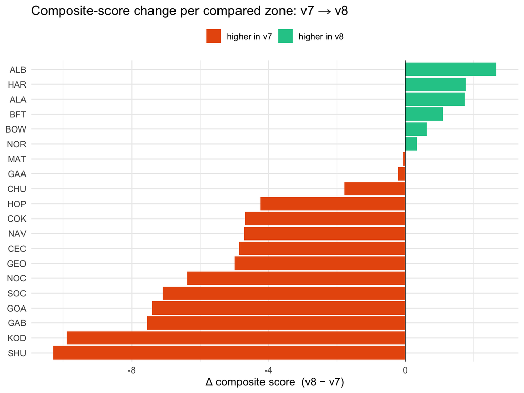

```r
d_plot <- d |>
  mutate(zone_key = factor(zone_key, levels = zone_key[order(delta)]),
         sign = ifelse(delta >= 0, glue("higher in {vb}"), glue("higher in {va}")))

ggplot(d_plot, aes(delta, zone_key, fill = sign)) +
  geom_col() +
  geom_vline(xintercept = 0, linewidth = 0.3) +
  scale_fill_manual(values = setNames(c("#20c997", "#e8590c"),
                                      c(glue("higher in {vb}"), glue("higher in {va}")))) +
  labs(x = glue("Δ composite score  ({vb} − {va})"), y = NULL, fill = NULL,
       title = glue("Composite-score change per compared zone: {va} → {vb}")) +
  theme_minimal(base_size = 12) +
  theme(legend.position = "top")
```

## 4 Component scores

`msens::zone_score_delta()` compares only shared zones and metrics and **returns what it had to drop**, so a component one release lacks is listed, never compared against nothing.

```r
is_component <- function(m) grepl("^extrisk_[a-z_]+_ecoregion_rescaled$", m) |
                            m == "primprod_ecoregion_rescaled"
comp_label <- function(m) ifelse(m == "primprod_ecoregion_rescaled", "primary productivity",
                                 sub("^extrisk_(.*)_ecoregion_rescaled$", "\\1", m))
comp_title <- function(m) tools::toTitleCase(gsub("_", " ", comp_label(m)))

comps <- zd$by_metric |>
  filter(is_component(metric_key)) |>
  mutate(component = comp_label(metric_key)) |>
  arrange(desc(mean_abs_delta))

only_a <- zd$metrics_only_a[is_component(zd$metrics_only_a)]
only_b <- zd$metrics_only_b[is_component(zd$metrics_only_b)]

cat(glue("- components compared: **{nrow(comps)}**  \n",
         "- components only in {va} (listed, not compared): ",
         if (length(only_a)) paste0("`", only_a, "`", collapse = ", ") else "none", "  \n",
         "- components only in {vb} (listed, not compared): ",
         if (length(only_b)) paste0("`", only_b, "`", collapse = ", ") else "none", "\n"))
```

```
- components compared: **7**
- components only in v7 (listed, not compared): `extrisk_other_ecoregion_rescaled`
- components only in v8 (listed, not compared): `extrisk_primary_producer_ecoregion_rescaled`
```

### 4.1 Summary by component

```r
comps |>
  transmute(component, metric_key, n = n_zones,
            !!glue("mean {va}") := round(mean_a, 2), !!glue("mean {vb}") := round(mean_b, 2),
            `mean Δ` = round(mean_delta, 2), `mean |Δ|` = round(mean_abs_delta, 2),
            `max |Δ|` = round(max_abs_delta, 2), r = round(cor, 3)) |>
  DT::datatable(rownames = FALSE, options = list(dom = "t", pageLength = 25),
                caption = glue("Per-component delta over the compared zones, {va} → {vb}, sorted by mean |Δ|"))
```

| component | metric_key | n | mean v7 | mean v8 | mean Δ | mean \|Δ\| | max \|Δ\| | r |
| --- | --- | --- | --- | --- | --- | --- | --- | --- |
| bird | extrisk_bird_ecoregion_rescaled | 20 | 53.98 | 37.79 | -16.2 | 20.09 | 54.56 | 0.687 |
| mammal | extrisk_mammal_ecoregion_rescaled | 20 | 52.55 | 50.65 | -1.9 | 9.89 | 22.36 | 0.808 |
| turtle | extrisk_turtle_ecoregion_rescaled | 11 | 39.07 | 33.02 | -6.05 | 8.62 | 19.75 | 0.908 |
| fish | extrisk_fish_ecoregion_rescaled | 20 | 22.4 | 23.78 | 1.38 | 7.71 | 27.41 | 0.821 |
| coral | extrisk_coral_ecoregion_rescaled | 20 | 13.5 | 13.66 | 0.15 | 0.84 | 5.57 | 0.994 |
| invertebrate | extrisk_invertebrate_ecoregion_rescaled | 20 | 21.09 | 20.63 | -0.46 | 0.83 | 2.21 | 0.998 |
| primary productivity | primprod_ecoregion_rescaled | 20 | 8.6 | 8.58 | -0.02 | 0.42 | 1.68 | 0.995 |

### 4.2 Δ by zone × component

One cell per (compared zone, component): Δ = B − A. Sort any column to find where a component moved most.

```r
comp_keys  <- comps$metric_key
comp_delta <- setNames(lapply(comp_keys, metric_delta), comp_keys)

wide <- bind_rows(
    lapply(comp_keys, function(m) comp_delta[[m]] |> transmute(zone_key, component = comp_label(m), delta)),
    d |> transmute(zone_key, component = "COMPOSITE", delta)) |>
  mutate(delta = round(delta, 2)) |>
  pivot_wider(names_from = component, values_from = delta) |>
  left_join(names_draw |> filter(status == "compared") |> select(key_b, zone_name, region), by = c("zone_key" = "key_b")) |>
  relocate(zone_key, zone_name, region, COMPOSITE) |>
  rename(Zone = zone_key, Name = zone_name, Region = region) |>
  arrange(desc(abs(COMPOSITE)))

num_cols <- names(wide)[sapply(wide, is.numeric)]
ds <- div_style(unlist(wide[num_cols]), n = 10)
DT::datatable(wide, rownames = FALSE, options = list(dom = "t", pageLength = 40, scrollX = TRUE),
              caption = glue("Δ ({vb} − {va}) per compared zone and component")) |>
  DT::formatStyle(num_cols, backgroundColor = DT::styleInterval(ds$brks, ds$cols))
```

| Zone | Name | Region | COMPOSITE | bird | mammal | turtle | fish | coral | invertebrate | primary productivity |
| --- | --- | --- | --- | --- | --- | --- | --- | --- | --- | --- |
| SHU | Shumagin | AK | -10.29 | -41.52 | -9.98 | -19.75 | -4.19 | -0.61 | -0.82 | 0 |
| KOD | Kodiak | AK | -9.91 | -36.43 | -10.41 | -17.31 | -2.86 | -0.88 | -1.22 | 0 |
| GAB | GOA Program Area B | GA | -7.55 | -54.56 | -8.8 | 9.04 | -0.79 | -0.12 | -0.8 | -0.02 |
| GOA | Gulf of Alaska | AK | -7.4 | -28.74 | -3.48 | -11.32 | -0.74 | -0.89 | -1.72 | -0.04 |
| SOC | Southern California | PA | -7.09 | -46.21 | -8.3 | -5.97 | 8.61 | -0.28 | 0.38 | 1.26 |
| NOC | Northern California | PA | -6.38 | -37.44 | -22.36 | -3.19 | 18.52 | -0.13 | -1.28 | 0.91 |
| GEO | St. George Basin | AK | -4.99 | -12.71 | -6.34 | -0.02 | -4.36 | -0.66 | -0.25 | -0.35 |
| CEC | Central California | PA | -4.85 | -41.71 | -9.45 | -4.06 | 17.5 | 0.22 | -0.52 | 1.62 |
| NAV | Navarin Basin | AK | -4.71 | -10.31 | -5.19 |  | -7.73 | 0.13 | 0.07 | -0.23 |
| COK | Cook Inlet | AK | -4.69 | -11.83 | 20.59 | -18.91 | -27.41 | -1.39 | -2.03 | -0.16 |

[output cut: 10 more lines]

### 4.3 Each component: map and table

**Bird**

`extrisk_bird_ecoregion_rescaled` — 20 zones compared; mean |Δ| 20.09, max |Δ| 54.56, r = 0.687.

[interactive chart not shown]

| Program Area (v8) | Name | Region | v7 | v8 | Δ | Δ % |
| --- | --- | --- | --- | --- | --- | --- |
| GAB | GOA Program Area B | GA | 85.68 | 31.12 | -54.56 | -63.7 |
| SOC | Southern California | PA | 63.37 | 17.15 | -46.21 | -72.9 |
| CEC | Central California | PA | 60.17 | 18.45 | -41.71 | -69.3 |
| SHU | Shumagin | AK | 71.97 | 30.44 | -41.52 | -57.7 |
| NOC | Northern California | PA | 48.32 | 10.89 | -37.44 | -77.5 |
| KOD | Kodiak | AK | 73.89 | 37.45 | -36.43 | -49.3 |
| GOA | Gulf of Alaska | AK | 73.33 | 44.59 | -28.74 | -39.2 |
| ALB | Aleutian Basin | AK | 16.47 | 36.22 | 19.75 | 119.9 |
| NOR | Norton Basin | AK | 91.85 | 73.94 | -17.91 | -19.5 |
| MAT | St. Matthew-Hall | AK | 78.96 | 64.67 | -14.29 | -18.1 |

[output cut: 10 more lines]

**Mammal**

`extrisk_mammal_ecoregion_rescaled` — 20 zones compared; mean |Δ| 9.89, max |Δ| 22.36, r = 0.808.

[interactive chart not shown]

| Program Area (v8) | Name | Region | v7 | v8 | Δ | Δ % |
| --- | --- | --- | --- | --- | --- | --- |
| NOC | Northern California | PA | 59.24 | 36.88 | -22.36 | -37.7 |
| COK | Cook Inlet | AK | 69.58 | 90.16 | 20.59 | 29.6 |
| NOR | Norton Basin | AK | 54 | 72.64 | 18.64 | 34.5 |
| MAT | St. Matthew-Hall | AK | 49.12 | 67.5 | 18.39 | 37.4 |
| BOW | Bowers Basin | AK | 57.88 | 45.78 | -12.1 | -20.9 |
| KOD | Kodiak | AK | 46.11 | 35.7 | -10.41 | -22.6 |
| HAR | High Arctic | AK | 4.24 | 14.62 | 10.38 | 244.9 |
| SHU | Shumagin | AK | 42.07 | 32.09 | -9.98 | -23.7 |
| CEC | Central California | PA | 54.14 | 44.69 | -9.45 | -17.4 |
| BFT | Beaufort Sea | AK | 19.16 | 28.27 | 9.11 | 47.5 |

[output cut: 10 more lines]

**Turtle**

`extrisk_turtle_ecoregion_rescaled` — 11 zones compared; mean |Δ| 8.62, max |Δ| 19.75, r = 0.908.

[interactive chart not shown]

| Program Area (v8) | Name | Region | v7 | v8 | Δ | Δ % |
| --- | --- | --- | --- | --- | --- | --- |
| SHU | Shumagin | AK | 46.47 | 26.73 | -19.75 | -42.5 |
| COK | Cook Inlet | AK | 48.66 | 29.75 | -18.91 | -38.9 |
| KOD | Kodiak | AK | 53.11 | 35.81 | -17.31 | -32.6 |
| GOA | Gulf of Alaska | AK | 69.58 | 58.26 | -11.32 | -16.3 |
| GAB | GOA Program Area B | GA | 26.38 | 35.43 | 9.04 | 34.3 |
| SOC | Southern California | PA | 26.76 | 20.8 | -5.97 | -22.3 |
| GAA | GOA Program Area A | GA | 54.56 | 59.63 | 5.06 | 9.3 |
| CEC | Central California | PA | 18.57 | 14.52 | -4.06 | -21.8 |
| NOC | Northern California | PA | 14.43 | 11.24 | -3.19 | -22.1 |
| ALA | Aleutian Arc | AK | 70.37 | 70.22 | -0.15 | -0.2 |

[output cut: 1 more lines]

**Fish**

`extrisk_fish_ecoregion_rescaled` — 20 zones compared; mean |Δ| 7.71, max |Δ| 27.41, r = 0.821.

[interactive chart not shown]

| Program Area (v8) | Name | Region | v7 | v8 | Δ | Δ % |
| --- | --- | --- | --- | --- | --- | --- |
| COK | Cook Inlet | AK | 69.97 | 42.57 | -27.41 | -39.2 |
| NOC | Northern California | PA | 11.27 | 29.8 | 18.52 | 164.3 |
| CEC | Central California | PA | 12.13 | 29.63 | 17.5 | 144.3 |
| ALA | Aleutian Arc | AK | 20.52 | 37.46 | 16.94 | 82.5 |
| BOW | Bowers Basin | AK | 7.84 | 24.22 | 16.38 | 208.8 |
| SOC | Southern California | PA | 23.36 | 31.97 | 8.61 | 36.9 |
| NAV | Navarin Basin | AK | 20.1 | 12.37 | -7.73 | -38.5 |
| ALB | Aleutian Basin | AK | 2.5 | 9.01 | 6.51 | 260.2 |
| NOR | Norton Basin | AK | 12.14 | 5.89 | -6.25 | -51.5 |
| MAT | St. Matthew-Hall | AK | 11.16 | 5.46 | -5.7 | -51.1 |

[output cut: 10 more lines]

**Coral**

`extrisk_coral_ecoregion_rescaled` — 20 zones compared; mean |Δ| 0.84, max |Δ| 5.57, r = 0.994.

[interactive chart not shown]

| Program Area (v8) | Name | Region | v7 | v8 | Δ | Δ % |
| --- | --- | --- | --- | --- | --- | --- |
| HOP | Hope Basin | AK | 47.8 | 53.37 | 5.57 | 11.6 |
| NOR | Norton Basin | AK | 5.72 | 7.16 | 1.44 | 25.1 |
| COK | Cook Inlet | AK | 27.49 | 26.09 | -1.39 | -5.1 |
| GAA | GOA Program Area A | GA | 11.99 | 13.25 | 1.26 | 10.5 |
| BFT | Beaufort Sea | AK | 7 | 5.78 | -1.22 | -17.4 |
| GOA | Gulf of Alaska | AK | 21.9 | 21.02 | -0.89 | -4 |
| KOD | Kodiak | AK | 13.85 | 12.97 | -0.88 | -6.3 |
| CHU | Chukchi Sea | AK | 14.24 | 13.5 | -0.74 | -5.2 |
| GEO | St. George Basin | AK | 26.55 | 25.89 | -0.66 | -2.5 |
| MAT | St. Matthew-Hall | AK | 4.75 | 5.37 | 0.62 | 13 |

[output cut: 10 more lines]

**Invertebrate**

`extrisk_invertebrate_ecoregion_rescaled` — 20 zones compared; mean |Δ| 0.83, max |Δ| 2.21, r = 0.998.

[interactive chart not shown]

| Program Area (v8) | Name | Region | v7 | v8 | Δ | Δ % |
| --- | --- | --- | --- | --- | --- | --- |
| HAR | High Arctic | AK | 15.31 | 17.53 | 2.21 | 14.4 |
| COK | Cook Inlet | AK | 44.1 | 42.06 | -2.03 | -4.6 |
| GOA | Gulf of Alaska | AK | 26.59 | 24.87 | -1.72 | -6.5 |
| NOR | Norton Basin | AK | 11.99 | 10.69 | -1.3 | -10.8 |
| NOC | Northern California | PA | 8.21 | 6.93 | -1.28 | -15.6 |
| KOD | Kodiak | AK | 19.19 | 17.97 | -1.22 | -6.4 |
| HOP | Hope Basin | AK | 68.17 | 66.95 | -1.22 | -1.8 |
| MAT | St. Matthew-Hall | AK | 12.33 | 11.22 | -1.11 | -9 |
| SHU | Shumagin | AK | 16.74 | 15.92 | -0.82 | -4.9 |
| GAB | GOA Program Area B | GA | 11.83 | 11.03 | -0.8 | -6.7 |

[output cut: 10 more lines]

**Primary Productivity**

`primprod_ecoregion_rescaled` — 20 zones compared; mean |Δ| 0.42, max |Δ| 1.68, r = 0.995.

[interactive chart not shown]

| Program Area (v8) | Name | Region | v7 | v8 | Δ | Δ % |
| --- | --- | --- | --- | --- | --- | --- |
| NOR | Norton Basin | AK | 20.04 | 18.36 | -1.68 | -8.4 |
| CEC | Central California | PA | 12 | 13.62 | 1.62 | 13.5 |
| SOC | Southern California | PA | 9.56 | 10.82 | 1.26 | 13.2 |
| NOC | Northern California | PA | 7.28 | 8.19 | 0.91 | 12.4 |
| MAT | St. Matthew-Hall | AK | 9.85 | 9.04 | -0.81 | -8.2 |
| HOP | Hope Basin | AK | 27.29 | 26.79 | -0.5 | -1.8 |
| GEO | St. George Basin | AK | 4.48 | 4.13 | -0.35 | -7.8 |
| NAV | Navarin Basin | AK | 2.99 | 2.76 | -0.23 | -7.8 |
| HAR | High Arctic | AK | 4.59 | 4.8 | 0.21 | 4.5 |
| COK | Cook Inlet | AK | 20.92 | 20.76 | -0.16 | -0.8 |

[output cut: 10 more lines]

### 4.4 Components present in only one version

Listed for reference, **not** compared: their score per zone in the version that has them.

```r
one_sided <- bind_rows(
  scores_a |> filter(metric_key %in% only_a) |> mutate(version = va, unit = unit_label[[unit_a]]),
  scores_b |> filter(metric_key %in% only_b) |> mutate(version = vb, unit = unit_label[[unit_b]]))
if (nrow(one_sided)) {
  one_sided |>
    transmute(version, unit, component = comp_label(metric_key), metric_key, zone = zone_key,
              score = round(score, 2)) |>
    DT::datatable(rownames = FALSE, filter = "top", options = list(pageLength = 25))
} else cat("none — both versions carry the same components.\n")
```

| version | unit | component | metric_key | zone | score |
| --- | --- | --- | --- | --- | --- |
| v7 | Program Area | other | extrisk_other_ecoregion_rescaled | ALA | 18.35 |
| v7 | Program Area | other | extrisk_other_ecoregion_rescaled | ALB | 4.92 |
| v7 | Program Area | other | extrisk_other_ecoregion_rescaled | BFT | 21.05 |
| v7 | Program Area | other | extrisk_other_ecoregion_rescaled | BOW | 9.6 |
| v7 | Program Area | other | extrisk_other_ecoregion_rescaled | CEC | 4.81 |
| v7 | Program Area | other | extrisk_other_ecoregion_rescaled | CHU | 33.87 |
| v7 | Program Area | other | extrisk_other_ecoregion_rescaled | COK | 41.24 |
| v7 | Program Area | other | extrisk_other_ecoregion_rescaled | GAA | 25.54 |
| v7 | Program Area | other | extrisk_other_ecoregion_rescaled | GAB | 5.77 |
| v7 | Program Area | other | extrisk_other_ecoregion_rescaled | GEO | 30.58 |

[output cut: 30 more lines]

## 5 All metrics, long form

Every (compared zone, metric) present in both versions — the composite, the components, and the intermediate metrics (`extrisk_*` raw, ecoregion min/max, pre-area-weighting backups). Filter with the boxes above each column and sort by any column.

```r
shared_m <- zd$by_metric$metric_key
long <- bind_rows(lapply(shared_m, function(m) metric_delta(m) |> mutate(metric_key = m))) |>
  left_join(names_draw |> filter(status == "compared") |> select(key_b, region), by = c("zone_key" = "key_b")) |>
  transmute(Zone = zone_key, Region = region, metric_key,
            !!va := round(.data[[va_col]], 3), !!vb := round(.data[[vb_col]], 3),
            `Δ` = round(delta, 3),
            `Δ %` = ifelse(.data[[va_col]] != 0, round(100 * delta / .data[[va_col]], 1), NA)) |>
  arrange(desc(abs(`Δ`)))
DT::datatable(long, rownames = FALSE, filter = "top",
              options = list(pageLength = 20, order = list(list(5, "desc"))),
              caption = glue("{nrow(long)} (zone × metric) pairs shared by {va} and {vb}"))
```

| Zone | Region | metric_key | v7 | v8 | Δ | Δ % |
| --- | --- | --- | --- | --- | --- | --- |
| GAB | GA | extrisk_bird_ecoregion_rescaled | 85.683 | 31.123 | -54.56 | -63.7 |
| GAB | GA | extrisk_bird_ecoregion_rescaled_prepctareaweighting | 85.683 | 31.183 | -54.5 | -63.6 |
| SOC | PA | extrisk_bird_ecoregion_rescaled | 63.369 | 17.154 | -46.214 | -72.9 |
| SOC | PA | extrisk_bird_ecoregion_rescaled_prepctareaweighting | 63.369 | 17.204 | -46.165 | -72.9 |
| CEC | PA | extrisk_bird_ecoregion_rescaled | 60.168 | 18.455 | -41.714 | -69.3 |
| CEC | PA | extrisk_bird_ecoregion_rescaled_prepctareaweighting | 60.168 | 18.481 | -41.688 | -69.3 |
| SHU | AK | extrisk_bird_ecoregion_rescaled | 71.965 | 30.444 | -41.522 | -57.7 |
| SHU | AK | extrisk_bird_ecoregion_rescaled_prepctareaweighting | 71.985 | 30.498 | -41.487 | -57.6 |
| NOC | PA | extrisk_bird_ecoregion_rescaled | 48.322 | 10.886 | -37.437 | -77.5 |
| NOC | PA | extrisk_bird_ecoregion_rescaled_prepctareaweighting | 48.322 | 10.908 | -37.414 | -77.4 |

[output cut: 272 more lines]

## 6 Across the nation: the v10 distribution share

Everything above is **within ecoregion**: a species’ importance in a Program Area is rescaled against the other cells of the *ecoregion* that Program Area sits in, so a quiet ecoregion’s best Program Area can outscore a busy ecoregion’s. The v10 score is **across the nation**: for each category the score is the Program Area’s risk-weighted share of each species’ distribution, divided by the area’s share of the nation, so **100 = the national-average concentration** and 250 holds two and a half times its area’s fair share. It is computed under three denominators (`global` = the species’ whole range, the headline; `usa` = its US slice; `pooled`), with the companion **percent of the world** beside it, and a category with too little coverage in a Program Area is **not reportable** (no row, never zero — the floor). This section runs only when version B carries score_v10_equalweights_global.

### How the national score is built

The rule is `msens::share_sql()` (unit-tested in `test-share.R`); in words, for each scored species *s* and category *g*:

1. **Value × area.** Each cell’s merged value (0–100) times its area: how much of the species’ habitat the cell holds.
2. **Divide by the denominator** (below): the species’ total, so its cells sum to a fixed amount.
3. **Weight by extinction risk** and **sum over the species of the category** in the Program Area.
4. **Per km², against the nation.** Divide the area’s total by the nation’s, and by the area’s share of the national area: **100 = the national-average concentration**; 200 = twice its fair share.
5. A category whose scored cells cover less than κ = 5 % of the area is **not reportable** (absent, never zero). The **composite** is the equal-weight mean of the reportable categories, productivity included.

**The three denominators** change only step 2, i.e. *how much each species can contribute in total*:

| denominator | each species is divided by | so a species counts | reads as |
| --- | --- | --- | --- |
| `global` (headline) | its total over its **whole modelled range**, worldwide | in proportion to the **fraction of its range in US waters** (× risk): a US-centred species counts fully, a species mostly elsewhere counts little | “how much of each species’ *world* distribution is here” |
| `usa` | its total over **US waters** only | **the same** for every species nationally (× risk), however widespread | “how much of each species’ *US* distribution is here”; areas add to 100 % of the nation |
| `pooled` | **nothing**: no per-species normalization | in proportion to its **habitat area × value**: widespread species dominate, narrow-range species weigh little | “how much habitat is here”; the RESA 1 arithmetic (value × area, then a percent of the national total) |

*Example.* A species found only in Cook Inlet gives Cook Inlet 100 % of its weight under `usa`. Under `global` that weight shrinks by the part of its range outside the US. Under `pooled` it counts only by its habitat area, so a small range adds little. Where the three agree, the choice does not matter for that area.

```r
mk_v10 <- params$metric_key_v10
mk_eco <- "score_extriskspcat_primprod_ecoregionrescaled_equalweights"
has_v10 <- unit_b == "programarea" &&
  "programarea_key" %in% msens::zone_scored_flds(con_b, mk_v10)
if (!has_v10) cat(glue("`{vb}` carries no Program-Area `{mk_v10}`: the v10 section is skipped."))
```

```
`v8` carries no Program-Area `score_v10_equalweights_global`: the v10 section is skipped.
```

```r
# vector helpers over the 20 Program Areas of B (A is already keyed onto B's zones)
pa <- st_drop_geometry(ply_b) |> select(zone_key, zone_name, region)
col_of <- function(df, m) {
  if (is.na(m)) return(rep(NA_real_, nrow(pa)))
  x <- df[df$metric_key == m, ]
  x$score[match(pa$zone_key, x$zone_key)]
}
rk <- function(x) rank(-x, ties.method = "min", na.last = "keep")             # 1 = highest
rho <- function(x, y) suppressWarnings(cor(x, y, method = "spearman", use = "pairwise.complete.obs"))
```

### 6.1 Re-issued Program-Area table

One row per Program Area: the published composite of **A**, B’s own **ecoregional** composite (B keeps v8’s within-ecoregion metrics unchanged, so this is the data rebuild alone), and the v10 across-the-nation composite under each denominator plus the floor-strip sensitivity (`global_strip`: the floor removed, so the areas it hides appear). Ranks run 1 = highest; Δrank = rank in A − rank in v10 global, so a positive value is a Program Area that moves **up** under v10.

```r
if (has_v10) {
  tab <- pa |> mutate(
    a      = col_of(scores_a_m, mk),
    eco    = col_of(scores_b, mk_eco),
    global = col_of(scores_b, mk_v10),
    usa    = col_of(scores_b, "score_v10_equalweights_usa"),
    pooled = col_of(scores_b, "score_v10_equalweights_pooled"),
    strip  = col_of(scores_b, "score_v10_equalweights_global_strip"),
    n_comp = col_of(scores_b, "score_v10_n_components_global")) |>
    mutate(across(c(a, eco, global, usa, pooled, strip), rk, .names = "rk_{.col}"),
           d_rank = rk_a - rk_global) |>
    arrange(desc(global))
  cols_v10 <- c("global", "usa", "pooled", "strip")
  rho_tab <- tibble(ranking = cols_v10,
                    `ρ vs A` = sapply(cols_v10, \(k) rho(tab[[k]], tab$a)),
                    `ρ vs B ecoregional` = sapply(cols_v10, \(k) rho(tab[[k]], tab$eco)))
  cap <- glue("Composite per Program Area, sorted by v10 global. Spearman ρ of the v10 ranking against ",
              "{va}'s / B's ecoregional: ",
              paste(glue("{rho_tab$ranking} {round(rho_tab[[2]], 2)} / {round(rho_tab[[3]], 2)}"), collapse = "; "))
  tab |>
    transmute(`Program Area` = zone_key, Name = zone_name,
              !!glue("{va} published") := round(a, 1), `B ecoregional` = round(eco, 1),
              `v10 global` = round(global, 1), `v10 usa` = round(usa, 1), `v10 pooled` = round(pooled, 1),
              `v10 global_strip` = round(strip, 1), `n components` = n_comp,
              !!glue("rank {va}") := rk_a, `rank B eco` = rk_eco, `rank global` = rk_global,
              `rank usa` = rk_usa, `rank pooled` = rk_pooled, `rank strip` = rk_strip,
              `Δrank` = d_rank) |>
    DT::datatable(rownames = FALSE, caption = cap,
                  options = list(pageLength = 25, dom = "t", scrollX = TRUE))
}
```

### 6.2 Per component

The same comparison one category at a time. The two ecoregional columns are the within-ecoregion component (A, B); `v10 global` is the across-the-nation score (100 = national average) with `% of world` — the share of the world’s risk-weighted distribution that sits in the Program Area — its number of species and the area’s `coverage`. **n/r** = not reportable: the category has coverage in the area but too little to publish a score (the floor), so no row exists.

```r
if (has_v10) {
  cats <- scores_b$metric_key |> unique()
  cats <- sort(unique(sub("^extrisk_(.*)_(v10_global|coverage)$", "\\1",
                          cats[grepl("^extrisk_(.*)_(v10_global|coverage)$", cats)])))
  spec <- bind_rows(
    tibble(component = cats,
           eco = glue("extrisk_{cats}_ecoregion_rescaled"), v10 = glue("extrisk_{cats}_v10_global"),
           cov = glue("extrisk_{cats}_coverage"), world = glue("extrisk_{cats}_pct_world"),
           nsp = glue("extrisk_{cats}_n_species"), usa = glue("extrisk_{cats}_v10_usa"),
           pooled = glue("extrisk_{cats}_v10_pooled")),
    tibble(component = "primprod", eco = "primprod_ecoregion_rescaled", v10 = "primprod_v10",
           cov = "primprod_coverage", world = NA_character_, nsp = NA_character_,
           usa = NA_character_, pooled = NA_character_))
  comp_tab <- purrr::pmap_dfr(spec, function(component, eco, v10, cov, world, nsp, usa, pooled) {
    cv <- col_of(scores_b, cov)
    # absent v10 row + coverage present = "n/r"; no coverage either = blank
    fmt <- function(v) ifelse(!is.na(v), sprintf("%.1f", v), ifelse(!is.na(cv), "n/r", ""))
    # .env$: the column named after version A (`va`, e.g. "v10") is built first in this tibble() and would
    # otherwise shadow the function argument of the same name inside the data mask (render of v10 vs v11, 2026-11-02)
    tibble(`Program Area` = pa$zone_key, Component = component,
           !!va := round(col_of(scores_a_m, .env$eco), 1), `B ecoregional` = round(col_of(scores_b, .env$eco), 1),
           `v10 global` = fmt(col_of(scores_b, .env$v10)), `% of world` = round(col_of(scores_b, .env$world), 2),
           coverage = round(cv, 3), `n species` = col_of(scores_b, .env$nsp),
           `v10 usa` = fmt(col_of(scores_b, .env$usa)), `v10 pooled` = fmt(col_of(scores_b, .env$pooled)))
  }) |>
    filter(!is.na(.data[[va]]) | !is.na(`B ecoregional`) | `v10 global` != "" | !is.na(coverage))
  DT::datatable(comp_tab, rownames = FALSE, filter = "top",
                options = list(pageLength = 25, scrollX = TRUE, order = list(list(1, "asc"))),
                caption = glue("Program Area × component: {va} and B ecoregional (within ecoregion) vs v10 (across the nation)"))
}
```

### 6.3 Attribution: v7 → v8 → v10

Two things changed between the published release and v10, and they are kept apart here. **A → B ecoregional** is the *data rebuild* (new models, same within-ecoregion scoring): both scores are on one scale, so it gets the usual deltas and gate statistics. **B ecoregional → v10 global** is the *scoring change*: the scale itself changes (a rescaled 0–100 index becomes a concentration index around 100), so a score delta is meaningless and it is reported as rank movement and Spearman ρ only.

```r
if (has_v10) {
  d_eco <- msens::score_delta(scores_a_m |> filter(metric_key == mk),
                              scores_b   |> filter(metric_key == mk_eco),
                              key = "zone_key", value = "score", labels = c(va, vb))
  s_eco <- msens::score_delta_summary(d_eco)
  step_tab <- tibble(
    step = c(glue("{va} → B ecoregional (data rebuild)"),
             "B ecoregional → v10 global (scoring change)", glue("{va} → v10 global (both)")),
    `same scale` = c("yes", "no", "no"), zones = c(s_eco$n, sum(!is.na(tab$eco + tab$global)), sum(!is.na(tab$a + tab$global))),
    `mean |Δ|` = c(round(s_eco$mean_abs, 2), NA, NA), `max |Δ|` = c(round(s_eco$max_abs, 2), NA, NA),
    `r` = c(round(cor(d_eco[[va_col]], d_eco[[vb_col]]), 3), NA, NA),
    `Spearman ρ` = round(c(rho(tab$a, tab$eco), rho(tab$eco, tab$global), rho(tab$a, tab$global)), 3))
}
```

```r
if (has_v10) knitr::kable(step_tab, caption = "Gate statistics per step (score deltas only where the scales match)")
```

```r
if (has_v10) {
  tab |>
    transmute(`Program Area` = zone_key, !!va := round(a, 1), `B ecoregional` = round(eco, 1),
              `v10 global` = round(global, 1), `Δ data (B eco − A)` = round(eco - a, 1),
              `rank A` = rk_a, `rank B eco` = rk_eco, `rank v10` = rk_global,
              `Δrank data` = rk_a - rk_eco, `Δrank scoring` = rk_eco - rk_global) |>
    arrange(desc(`v10 global`)) |>
    DT::datatable(rownames = FALSE, options = list(pageLength = 25, dom = "t", scrollX = TRUE),
                  caption = "Per Program Area: the data-rebuild delta and the scoring-change rank move (positive = moves up)")
}
```

### 6.4 Sea turtles by species

Turtles are the category the across-the-nation view changes most: a few Program Areas hold nearly all of a species’ world distribution weight while most hold none. For each Program Area and species, `share_global` is the share of the **world** distribution (risk-weighted) inside the area, `share_usa` the share of the species’ **US slice**, and `share_v10_contrib` its contribution to the area’s turtle total under the headline global denominator. Areas are ordered by region (Alaska, Pacific, Gulf, Atlantic).

```r
if (has_v10) {
  zc <- msens::sdm_val_col(con_b, "zone")
  # region of a Program Area = the subregion covering most of its cells
  reg <- tryCatch(dbGetQuery(con_b, glue("
      SELECT pa.{zc} AS zone_key, s.{zc} AS subregion, count(*) AS n
      FROM zone pa JOIN zone_cell zp ON zp.zone_seq = pa.zone_seq
      JOIN zone_cell zs ON zs.cell_id = zp.cell_id JOIN zone s ON s.zone_seq = zs.zone_seq
      WHERE pa.fld = 'programarea_key' AND s.fld = 'subregion_key'
      GROUP BY 1, 2")) |> as_tibble() |> group_by(zone_key) |> slice_max(n, n = 1, with_ties = FALSE) |>
      ungroup() |> select(zone_key, subregion),
    error = function(e) tibble(zone_key = character(), subregion = character()))
  reg_ord <- c("AK", "PA", "GA", "AT")                       # Alaska, Pacific, Gulf, Atlantic
  zt <- dbGetQuery(con_b, "SELECT zone_value AS zone_key, mdl_key, sp_common, sp_scientific,
                             share_usa, share_global, share_v10_contrib
                           FROM zone_taxon WHERE sp_cat = 'turtle' AND zone_fld = 'programarea_key'") |>
    as_tibble() |> mutate(species = coalesce(sp_common, sp_scientific))
  turt <- pa |> select(zone_key, zone_name) |>
    left_join(reg, by = "zone_key") |>
    left_join(zt |> mutate(share_global = round(100 * share_global, 2)) |>
                select(zone_key, species, share_global) |>
                pivot_wider(names_from = species, values_from = share_global), by = "zone_key") |>
    mutate(`turtle v10 global` = round(col_of(scores_b, "extrisk_turtle_v10_global"), 1)[match(zone_key, pa$zone_key)],
           `% of world` = round(col_of(scores_b, "extrisk_turtle_pct_world"), 2)[match(zone_key, pa$zone_key)],
           ord = match(subregion, reg_ord, nomatch = 99L)) |>
    arrange(ord, zone_key) |> select(-ord) |> rename(`Program Area` = zone_key, Name = zone_name, Region = subregion)
}
```

```r
# one row per Program Area, a column per species: % of the world's distribution inside the area
if (has_v10) {
  DT::datatable(turt, rownames = FALSE, options = list(pageLength = 25, dom = "t", scrollX = TRUE),
                caption = "Sea turtles: world share (%) per species and the Program Area's turtle v10 score") |>
    DT::formatRound(setdiff(names(turt)[sapply(turt, is.numeric)], "turtle v10 global"), 2)
}
```

```r
if (has_v10) {
  zt |> transmute(`Program Area` = zone_key, Species = species, `share usa` = signif(share_usa, 3),
                  `share global` = signif(share_global, 3), `contribution to v10` = signif(share_v10_contrib, 3)) |>
    DT::datatable(rownames = FALSE, filter = "top", options = list(pageLength = 15),
                  caption = "Long form: every (Program Area, turtle species) row of zone_taxon")
}
```

### 6.5 The three denominators

The same composite under the three denominators (defined in How the national score is built), one row per Program Area sorted by the global headline. Where the three dots coincide the denominator does not matter; where they spread, the answer depends on whether each species is weighed by its share of its **world** range (`global`), of its **US** range (`usa`), or by its raw **habitat area** (`pooled`). All three are relative to the national average, so a spread says how an area’s species differ from the nation’s mix: higher under `global` than under `usa` = its species are more US-centred than most; higher under `global` than under `pooled` = more of its weight comes from narrow-range species. The dashed line is 100, the national average.

```r
if (has_v10) {
  den <- tab |> select(zone_key, global, usa, pooled) |>
    pivot_longer(-zone_key, names_to = "denominator", values_to = "score") |>
    mutate(zone_key = factor(zone_key, levels = tab$zone_key[order(tab$global, na.last = FALSE)]),
           denominator = factor(denominator, c("global", "usa", "pooled")))
  # Okabe-Ito: colour-blind safe
  pal <- c(global = "#0072B2", usa = "#E69F00", pooled = "#009E73")
  g <- ggplot(den, aes(score, zone_key, colour = denominator)) +
    geom_line(aes(group = zone_key), colour = "grey70", linewidth = 0.5, na.rm = TRUE) +
    geom_vline(xintercept = 100, linetype = "dashed", linewidth = 0.4) +
    geom_point(size = 2.6, na.rm = TRUE) +
    scale_colour_manual(values = pal) +
    labs(x = glue("{vb} national composite  (100 = national average{if (all(den$score > 0, na.rm = TRUE)) '; log scale' else ''})"),
         y = NULL, colour = "denominator",
         title = glue("Across-the-nation composite under three denominators ({vb})")) +
    theme_minimal(base_size = 12) + theme(legend.position = "top")
  # log axis when every score is positive (a concentration index spans orders of magnitude)
  if (all(den$score > 0, na.rm = TRUE)) g <- g + scale_x_log10()
  g
}
```

### 6.6 Method flags

What the release states about how v10 was built (`release_method`).

```r
if (has_v10 && DBI::dbExistsTable(con_b, "release_method")) {
  dbGetQuery(con_b, "SELECT method_key, value, description FROM release_method ORDER BY method_key") |>
    knitr::kable(caption = glue("release_method of {vb}"))
} else if (has_v10) cat(glue("`{vb}` has no `release_method` table.\n"))
```

## 7 Attribution: which flag moved which score

This section runs only when version B has an attribution set (`data/{vb}/attribution/`, today only v11) **and** version A is B’s `prev` in `data/versions.csv`, since the attribution’s control run reproduces that release (v11’s control reproduces v10).

v11 changes the method in eight independent ways, each a flag in `libs/vars.R`. The **control** run has every flag at its v10 value (so it reproduces v10); the **candidate** has every flag on. Each other run is the candidate with **one** flag back at its control value (`no_<flag>`, and `nc_atl_2018` for the Atlantic bird source), so the candidate minus that run is what the flag owns. Three settings were decided **after** the candidate and are shown as steps of their own in After the candidate. `scripts/attribution_runs.sh` makes the runs and `snapshot_scores.qmd` writes each run’s zone scores to `data/v11/attribution/{variant}.parquet`; this section reads whatever of that set exists, says which runs are missing, and computes every number below from the files. It reads no `sdm.duckdb`.

**What each flag means**

[output not shown]

and, decided after the candidate:

[output not shown]

```r
# the registry of variants and their single flag swaps is PARSED from the runner, so it cannot drift
att_dir <- here::here("data", vb, "attribution")
vers_csv <- readr::read_csv(here::here("data/versions.csv"), show_col_types = FALSE)
prev_b   <- vers_csv$prev[match(vb, vers_csv$ver)]
att_ok   <- dir.exists(att_dir) && identical(prev_b, va)
if (!att_ok) cat(glue("No attribution for {va} vs {vb} (needs `data/{vb}/attribution/` and `prev` of {vb} = {va}): the section is skipped.\n\n"))
```

No attribution for v7 vs v8 (needs `data/v8/attribution/` and `prev` of v8 = v7): the section is skipped.

```r
runs_sh <- readLines(here::here("scripts/attribution_runs.sh"), warn = FALSE)
sh_get  <- function(key) sub(sprintf('^%s="([^"]*)".*$', key), "\\1", grep(sprintf('^%s="', key), runs_sh, value = TRUE))[1]   # a trailing comment is allowed
kv      <- strsplit(strsplit(sh_get("FULL"), " ")[[1]], "=")
cand_kv <- tibble(flag = tolower(sapply(kv, `[`, 1)), candidate = sapply(kv, `[`, 2))
variants_all <- strsplit(sh_get("VARIANTS"), " ")[[1]]
variants_extra <- strsplit(sh_get("EXTRA_VARIANTS"), " ")[[1]]   # follow-ups on the candidate (full2023_cal = + FOLD_DENSITY_CAL=mass), not in --all
variants_extra <- variants_extra[!is.na(variants_extra) & nzchar(variants_extra)]
sw <- regmatches(runs_sh, regexec('^\\s*(\\w+)\\)\\s+echo "\\$\\{FULL/(\\w+)=([^/]+)/\\w+=([^}]+)\\}"', runs_sh, perl = TRUE))
sw <- sw[lengths(sw) == 5]
# the runner spells booleans 0/1, the snapshots TRUE/FALSE
bool <- \(x) ifelse(x == "1", "TRUE", ifelse(x == "0", "FALSE", x))
swaps <- tibble(variant = sapply(sw, `[`, 2), flag = tolower(sapply(sw, `[`, 3)),
                on = bool(sapply(sw, `[`, 4)), off = bool(sapply(sw, `[`, 5)))

# the component labels (v11 names: Flora, Productivity) by component stem
comp_lab <- readr::read_csv(here::here("data/components.csv"), show_col_types = FALSE) |>
  select(stem = key, label, label_v10)

att_files <- if (att_ok) list.files(att_dir, "\\.parquet$", full.names = TRUE) else character()
att <- if (length(att_files)) bind_rows(lapply(att_files, arrow::read_parquet)) else tibble()
flag_cols <- setdiff(names(att), c("ver", "variant", "zone_set_key", "zone_fld", "zone_value", "metric_key", "val"))
# a snapshot taken before a flag existed lacks its column: that flag was at its control value then
if (nrow(att)) {
  if (!"nc_atl_source" %in% names(att)) att$nc_atl_source <- NA_character_
  if (!"fold_density_cal" %in% names(att)) att$fold_density_cal <- NA_character_
  if (!"share_basis" %in% names(att)) att$share_basis <- NA_character_
  if (!"range_fill" %in% names(att)) att$range_fill <- NA_character_
  att <- att |> mutate(nc_atl_source = coalesce(nc_atl_source, "2018"), fold_density_cal = coalesce(fold_density_cal, "none"),
                       share_basis = coalesce(share_basis, "taxon"), range_fill = coalesce(range_fill, "er"))   # SHARE_BASIS / RANGE_FILL (2026-11-02)
  flag_cols <- union(flag_cols, c("share_basis", "range_fill"))
}
present <- unique(att$variant)

cand <- c("full2023", "full")[c("full2023", "full") %in% present][1]
has_att <- att_ok && length(present) > 0 && "control" %in% present && !is.na(cand)
cand_note <- if (!att_ok) {
  ""
} else if (!has_att) {
  "The attribution needs at least `control` and a candidate (`full2023` or `full`); the section is skipped."
} else if (cand == "full") {
  "`full2023` (the candidate) is not yet snapshotted: every comparison below uses **`full`** (every flag on, the 2018 Atlantic bird source) as the candidate until it exists."
} else {
  "The candidate is **`full2023`**; `full` (the same with the 2018 Atlantic bird source) is shown as a run of its own."
}
cat(cand_note, "\n")
```

### 7.1 Variants

```r
if (has_att) {
  flag_of <- att |> distinct(variant, across(all_of(flag_cols))) |> mutate(across(everything(), as.character))
  cand_flags <- flag_of[flag_of$variant == cand, flag_cols, drop = FALSE]
  differs <- function(v) {
    if (v %in% present) {
      f <- flag_of[flag_of$variant == v, flag_cols, drop = FALSE]
      d <- flag_cols[unlist(f[1, ]) != unlist(cand_flags[1, ])]
      if (!length(d)) return(if (v == cand) "(the candidate)" else "(none)")
      paste(sprintf("%s=%s", d, unlist(f[1, d])), collapse = ", ")
    } else if (v %in% swaps$variant) {
      s <- swaps[swaps$variant == v, ]
      sprintf("%s=%s", s$flag, s$off)
    } else if (v == "full2023") "(the candidate: every flag on, nc_atl_source=2023)" else "?"
  }
  vt <- tibble(variant = unique(c("control", "full", variants_all, variants_extra))) |>
    mutate(role = case_when(variant == cand ~ "candidate", variant == "control" ~ "control (== v10)",
                            variant %in% swaps$variant ~ "one flag at its control value",
                            variant %in% variants_extra ~ "the candidate + a follow-up setting",
                            TRUE ~ "all flags on"),
           `differs from the candidate` = sapply(variant, differs),
           status = ifelse(variant %in% present, "present", "MISSING"),
           `zone-metric rows` = sapply(variant, \(v) sum(att$variant == v)))
  miss <- vt$variant[vt$status == "MISSING"]
  knitr::kable(vt, caption = glue("{sum(vt$status == 'present')} of {nrow(vt)} variants present"))
}
```

```r
if (has_att) cat(if (length(miss)) glue("**Missing variants:** {paste0('`', miss, '`', collapse = ', ')}. Their flags have no attribution row below until `scripts/attribution_runs.sh` has run them and `snapshot_scores` has written the file; every table lists only what exists.\n")
                 else "All variants are present.\n")
```

```r
if (has_att) {
  PA <- "programarea_key"
  att_pa <- att |> filter(zone_fld == PA)
  m_nat <- "score_v10_equalweights_global"
  m_eco <- grep("^score_.*ecoregion", unique(att_pa$metric_key), value = TRUE)[1]
  vec <- function(v, metric, d = att_pa) {
    x <- d[d$variant == v & d$metric_key == metric, ]
    setNames(x$val, x$zone_value)
  }
  area_nm <- function(k) if (exists("pa") && "zone_name" %in% names(pa)) pa$zone_name[match(k, pa$zone_key)] else NA_character_
  # one-flag variants that exist, in the runner's order, with the flag each owns
  singles <- swaps |> filter(variant %in% present, variant %in% variants_all) |>
    mutate(ord = match(variant, variants_all)) |> arrange(ord)
  # x, y = named vectors by area; deltas on the areas where both exist
  delta_stats <- function(x, y) {
    k <- intersect(names(x), names(y)); k <- k[!is.na(x[k]) & !is.na(y[k])]
    if (!length(k)) return(tibble(areas = 0L, `mean |Δ|` = NA_real_, `max |Δ|` = NA_real_, `at` = NA_character_, r = NA_real_, `Spearman ρ` = NA_real_))
    d <- abs(y[k] - x[k])
    tibble(areas = length(k), `mean |Δ|` = mean(d), `max |Δ|` = max(d), `at` = k[which.max(d)],
           r = if (length(k) > 2) cor(x[k], y[k]) else NA_real_,
           `Spearman ρ` = if (length(k) > 2) cor(x[k], y[k], method = "spearman") else NA_real_)
  }
  runs_vs_cand <- setdiff(intersect(c("control", "full", singles$variant), present), cand)
  mets <- c(national = m_nat, `ecoregion-rescaled` = m_eco)
  cat(glue("Program-Area composites: national `{m_nat}`; ecoregion-rescaled `{m_eco}`.\n"))
}
```

### 7.2 Headline attribution

Each row compares one run with the candidate on the 20 Program Areas (areas where both runs have a score): the mean and maximum absolute difference, the area of the maximum, and the Pearson r and Spearman ρ between the two sets of scores. The **control** row is the whole change (v10 → candidate); each `no_<flag>` row is what removing that one flag does. The national composite is the v10 concentration index (100 = national average); the ecoregion-rescaled composite is a 0–100 index, so their Δ are on different scales.

```r
if (has_att) {
  for (nm in names(mets)) {
    mm <- mets[[nm]]
    cat(glue("\n\n**{nm} composite** (`{mm}`)\n\n"))
    h <- purrr::map_dfr(runs_vs_cand, \(v) bind_cols(tibble(`run vs candidate` = v), delta_stats(vec(cand, mm), vec(v, mm)))) |>
      left_join(swaps |> select(`run vs candidate` = variant, flag), by = "run vs candidate") |>
      mutate(`flag it removes` = ifelse(is.na(flag), ifelse(`run vs candidate` == "control", "all", ""), flag), .after = 1) |>
      select(-flag) |>
      mutate(across(c(`mean |Δ|`, `max |Δ|`), \(x) round(x, 2)), across(c(r, `Spearman ρ`), \(x) round(x, 3)))
    if (nrow(h)) print(knitr::kable(h, caption = glue("{nm}: runs vs the candidate `{cand}`"))) else cat("No run to compare yet.\n")
  }
}
```

#### 7.2.1 Per Program Area: the delta each flag owns

For each Program Area: the candidate’s score, the control’s, and the delta each flag owns (candidate minus the run without that flag). **sum of flag deltas** adds the single-flag deltas of the flags present; **candidate − control** is the whole change. The difference between the two is the **interaction**: what the flags do together that none does alone (or the flags whose run is still missing).

```r
area_tab <- function(mm) {
  ck <- vec(cand, mm); k0 <- vec("control", mm)
  keys <- names(ck)
  out <- tibble(`Program Area` = keys, Name = area_nm(keys), candidate = unname(ck), control = unname(k0[keys]))
  for (i in seq_len(nrow(singles))) out[[singles$flag[i]]] <- unname(ck[keys] - vec(singles$variant[i], mm)[keys])
  fl <- if (nrow(singles)) singles$flag else character()
  out |> mutate(`sum of flag deltas` = if (length(fl)) rowSums(across(all_of(fl)), na.rm = TRUE) else NA_real_,
                `candidate − control` = candidate - control,
                interaction = `candidate − control` - `sum of flag deltas`) |>
    arrange(desc(candidate))
}
area_dt <- function(nm) {
  at <- area_tab(mets[[nm]])
  DT::datatable(at, rownames = FALSE, options = list(pageLength = 20, dom = "t", scrollX = TRUE),
                caption = glue("{nm}: candidate `{cand}`, control, and the delta each flag owns (candidate minus the run without it); flags present: ",
                               "{if (nrow(singles)) paste(singles$flag, collapse = ', ') else 'none'}")) |>
    DT::formatRound(setdiff(names(at), c("Program Area", "Name")), 1)
}
```

**National composite**

```r
if (has_att) area_dt("national")
```

**Ecoregion-rescaled composite**

```r
if (has_att) area_dt("ecoregion-rescaled")
```

### 7.3 Components

The same comparison for each component score under the national scoring (`extrisk_{category}_v10_global` and `primprod_v10`), over the Program Areas: per flag and component, the mean and maximum |Δ| where both runs report it, and the Program Areas where the flag **adds** the component (the candidate reports it, the run without the flag does not) or **removes** it (the reverse). An absent row is a component with too little coverage in that area to report under the 5 % floor, never a zero. Labels are the v11 names from `data/components.csv`.

```r
if (has_att) {
  cmet <- grep("^(extrisk_.*_v10_global|primprod_v10)$", unique(att_pa$metric_key), value = TRUE)
  cstem <- ifelse(cmet == "primprod_v10", "primprod", sub("^extrisk_(.*)_v10_global$", "\\1", cmet))
  clab  <- comp_lab$label[match(cstem, comp_lab$stem)]
  clab  <- ifelse(is.na(clab), cstem, clab)
  runs_c <- c(control = "control", setNames(singles$variant, singles$flag))
  runs_c <- runs_c[runs_c %in% present & runs_c != cand]
  ct <- purrr::map_dfr(names(runs_c), \(fl) purrr::map_dfr(seq_along(cmet), \(i) {
    x <- vec(cand, cmet[i]); y <- vec(runs_c[[fl]], cmet[i])
    s <- delta_stats(x, y)
    tibble(`flag removed` = fl, Component = clab[i], `both report` = s$areas,
           `mean |Δ|` = s$`mean |Δ|`, `max |Δ|` = s$`max |Δ|`, `at` = s$at,
           `flag adds it in` = paste(sort(setdiff(names(x), names(y))), collapse = " "),
           `flag removes it in` = paste(sort(setdiff(names(y), names(x))), collapse = " "))
  }))
  if (nrow(ct)) {
    wide <- ct |> select(`flag removed`, Component, `mean |Δ|`) |>
      mutate(`mean |Δ|` = round(`mean |Δ|`, 2)) |> pivot_wider(names_from = Component, values_from = `mean |Δ|`)
    print(knitr::kable(wide, caption = glue("Mean |Δ| per Program Area, candidate `{cand}` minus the run without the flag ('control' = every flag removed)")))
  } else cat("No run to compare yet.\n")
}
```

```r
if (has_att && exists("ct") && nrow(ct)) {
  DT::datatable(ct |> mutate(across(c(`mean |Δ|`, `max |Δ|`), \(x) round(x, 2))), rownames = FALSE, filter = "top",
                options = list(pageLength = 20, scrollX = TRUE),
                caption = glue("Flag × component over Program Areas. flag adds it in = areas where `{cand}` reports the component and the run without the flag does not; flag removes it in = the reverse"))
}
```

### 7.4 After the candidate: single counting and the range fill

The candidate above still counts extinction risk the v4–v10 way. Three settings decided on 2026-11-02 (see What each flag means) take it to the published release, one step at a time:

1. **single counting** where a suitability model covers the range cell (`share_basis = cell`), keeping the risk score on unmodelled range cells (`range_fill = er`);
2. **the mean fill**: an unmodelled range cell takes the mean of the species’ modelled range cells (`range_fill = mean`) instead of its risk score;
3. **the survey calibration** on the suitability prior (`fold_density_cal = suit`): this gives the published **v11**.

`presence` (an unmodelled range cell = 100) was measured as the alternative to step 2 and is shown beside it.

```r
STEPS <- tibble(
  variant = c(if (exists("cand")) cand else NA_character_, "full2023_basis_er", "full2023_basis_mean", "v11"),
  step    = c("candidate", "1 single counting (er fill)", "2 mean fill", "3 calibration = v11"))
alt_step <- tibble(variant = "full2023_basis", step = "alt: presence fill")
has_steps <- has_att && all(STEPS$variant %in% present)
if (has_att && !has_steps)
  cat(glue("Steps missing from `data/{vb}/attribution/`: {paste(setdiff(STEPS$variant, present), collapse = ', ')}; the subsection is skipped.\n"))
```

```r
if (has_steps) {
  st <- bind_rows(STEPS, alt_step |> filter(variant %in% present))
  prev_of <- c(setNames(STEPS$variant[-nrow(STEPS)], STEPS$variant[-1]), full2023_basis = "full2023_basis_er")
  for (nm in names(mets)) {
    mm <- mets[[nm]]
    s_tab <- purrr::map_dfr(st$variant[-1], \(v) bind_cols(
      tibble(step = st$step[st$variant == v], `from → to` = glue("{prev_of[[v]]} → {v}")),
      delta_stats(vec(prev_of[[v]], mm), vec(v, mm)))) |>
      bind_rows(bind_cols(tibble(step = "all steps", `from → to` = glue("{cand} → v11")), delta_stats(vec(cand, mm), vec("v11", mm))),
                bind_cols(tibble(step = "whole change", `from → to` = glue("control ({va}) → v11")), delta_stats(vec("control", mm), vec("v11", mm)))) |>
      mutate(across(c(`mean |Δ|`, `max |Δ|`), \(x) round(x, 2)), across(c(r, `Spearman ρ`), \(x) round(x, 3)))
    print(knitr::kable(s_tab, caption = glue("{nm} composite: each step vs the one before it, over the Program Areas")))
  }
}
```

```r
if (has_steps) {
  stp <- bind_rows(tibble(variant = "control", step = glue("control ({va})")), STEPS)
  w <- purrr::map_dfc(seq_len(nrow(stp)), \(i) {
    x <- vec(stp$variant[i], m_nat); tibble(!!stp$step[i] := unname(x[names(vec(cand, m_nat))]))
  })
  at <- bind_cols(tibble(`Program Area` = names(vec(cand, m_nat)), Name = area_nm(names(vec(cand, m_nat)))), w) |>
    mutate(`Δ steps 1–3` = .data[["3 calibration = v11"]] - .data[["candidate"]],
           `Δ control → v11` = .data[["3 calibration = v11"]] - .data[[glue("control ({va})")]]) |>
    arrange(desc(.data[["3 calibration = v11"]]))
  DT::datatable(at, rownames = FALSE, options = list(pageLength = 20, dom = "t", scrollX = TRUE),
                caption = "National composite per Program Area at each step (100 = national average)") |>
    DT::formatRound(setdiff(names(at), c("Program Area", "Name")), 1)
}
```

```r
if (has_steps) {
  stp <- bind_rows(tibble(variant = "control", step = glue("control ({va})")), STEPS)
  sp <- purrr::map_dfr(seq_len(nrow(stp)), \(i) {
    x <- vec(stp$variant[i], m_nat); tibble(step = stp$step[i], area = names(x), score = unname(x))
  }) |> mutate(area = factor(area, names(sort(vec("v11", m_nat)))), step = factor(step, stp$step))
  pal_s <- setNames(c("grey55", "#000000", "#E69F00", "#56B4E9", "#D55E00"), stp$step)
  shp_s <- setNames(c(21, 16, 16, 16, 18), stp$step)
  ggplot(sp, aes(score, area)) +
    geom_line(aes(group = area), colour = "grey80", linewidth = 0.5, na.rm = TRUE) +
    geom_point(aes(colour = step, shape = step), size = 2.8, fill = "white", na.rm = TRUE) +
    geom_vline(xintercept = 100, linetype = "dashed", linewidth = 0.4) +
    scale_colour_manual(values = pal_s) + scale_shape_manual(values = shp_s) +
    labs(x = glue("national composite {m_nat}  (100 = national average)"), y = NULL, colour = NULL, shape = NULL,
         title = glue("Program Areas: control ({va}) → candidate → single counting → mean fill → v11")) +
    theme_minimal(base_size = 11) + theme(legend.position = "top")
}
```

### 7.5 The occurrence rule’s reach

The occurrence rule (`occ_rule`) gates a species out of an ecoregion where it has **no OBIS record** under adequate search effort; where it is recorded but rarely, `region_weight` downweights it by its encounter weight `w` there (its record rate in the ecoregion over its rate elsewhere). `data/v11/zone_exclusions_occ.csv` holds the gated pairs and `data/v11/zone_weights_occ.csv` the weighted ones (a gated pair is `w = 0` there); both come from the exploration notebook. The denominator is each component’s species count in the ecoregion (`extrisk_{category}_n_species`) of the run without the rule, so the percentage is the share of the component’s species there that the rule touches.

```r
f_ex <- here::here("data", vb, "zone_exclusions_occ.csv"); f_w <- here::here("data", vb, "zone_weights_occ.csv")
has_occ <- has_att && file.exists(f_ex) && file.exists(f_w)
if (has_att && !has_occ) cat("The occurrence-rule CSVs are not on disk: this subsection is skipped.\n")
if (has_occ) {
  ex <- readr::read_csv(f_ex, show_col_types = FALSE)
  wt <- readr::read_csv(f_w,  show_col_types = FALSE)
  base_run <- c("no_occ_rule", "control")[c("no_occ_rule", "control") %in% present][1]
  den <- att |> filter(zone_fld == "ecoregion_key", variant == base_run, grepl("^extrisk_.*_n_species$", metric_key)) |>
    transmute(ecoregion = zone_value, sp_cat = sub("^extrisk_(.*)_n_species$", "\\1", metric_key), n_in_zone = val)
  gated <- ex |> distinct(mdl_key, ecoregion = zone_key, sp_cat) |> count(ecoregion, sp_cat, name = "gated")
  wtd   <- wt |> filter(w > 0, w < 1) |> group_by(ecoregion = zone_key, sp_cat) |>
    summarise(weighted = n_distinct(mdl_key), `median w` = median(w), .groups = "drop")
  reach <- full_join(gated, wtd, by = c("ecoregion", "sp_cat")) |>
    left_join(den, by = c("ecoregion", "sp_cat")) |>
    mutate(across(c(gated, weighted), \(x) coalesce(x, 0L)),
           affected = gated + weighted,
           `% of the component's species` = 100 * affected / n_in_zone,
           Component = coalesce(comp_lab$label[match(sp_cat, comp_lab$stem)], sp_cat)) |>
    arrange(ecoregion, sp_cat)
  cat(glue("Species counts from `{base_run}`; {nrow(ex)} gated and {sum(wt$w > 0 & wt$w < 1)} downweighted ",
           "(species, ecoregion) pairs over {n_distinct(c(ex$mdl_key, wt$mdl_key))} species.\n"))
}
```

```r
if (has_occ && nrow(reach)) {
  reach |> transmute(Ecoregion = ecoregion, Component, `species in zone` = n_in_zone, gated, weighted,
                     `median w` = round(`median w`, 3), `% affected` = round(`% of the component's species`, 1)) |>
    DT::datatable(rownames = FALSE, filter = "top", options = list(pageLength = 15, scrollX = TRUE),
                  caption = "Occurrence rule: species gated (w = 0) and downweighted (0 < w < 1) per ecoregion and component")
}
```

```r
if (has_occ && nrow(reach)) {
  reach |> transmute(Ecoregion = ecoregion, Component, pct = round(`% of the component's species`, 1)) |>
    pivot_wider(names_from = Component, values_from = pct) |>
    knitr::kable(caption = "Share (%) of each component's species in the ecoregion that the rule gates or downweights")
}
```

```r
if (has_occ) {
  mt <- c("mammal", "turtle")
  g <- ex |> filter(sp_cat %in% mt) |>
    transmute(Ecoregion = zone_key, Component = comp_lab$label[match(sp_cat, comp_lab$stem)], Species = scientific_name,
              `Common name` = common_name, w = 0, `n searched` = n_searched, `n occupied` = n_occupied, Reason = reason) |>
    arrange(Component, Species, Ecoregion)
  if (nrow(g)) DT::datatable(g, rownames = FALSE, filter = "top", options = list(pageLength = 10, scrollX = TRUE),
                             caption = glue("Marine mammal and sea turtle pairs gated out ({nrow(g)}; w = 0)"))
}
```

```r
if (has_occ) {
  lo <- wt |> filter(sp_cat %in% c("mammal", "turtle"), w > 0, w < 1) |> arrange(w) |> slice_head(n = 20) |>
    transmute(Ecoregion = zone_key, Component = comp_lab$label[match(sp_cat, comp_lab$stem)], Species = scientific_name,
              `Common name` = common_name, w = signif(w, 3), `n searched` = n_searched, `n occupied` = n_occupied,
              rate = signif(rate, 3), `baseline rate` = signif(p_core, 3))
  if (nrow(lo)) knitr::kable(lo, caption = "The 20 most downweighted marine mammal and sea turtle pairs that are not gated (smallest w > 0)")
}
```

### 7.6 Figures

```r
if (has_att) {
  run_ord <- c("control", singles$variant, cand) |> unique() |> intersect(present)
  lp <- purrr::map_dfr(run_ord, \(v) tibble(run = v, area = names(vec(v, m_nat)), score = unname(vec(v, m_nat))))
  area_lv <- names(sort(vec(cand, m_nat)))
  lp <- lp |> mutate(area = factor(area, area_lv), run = factor(run, run_ord))
  # Okabe-Ito for the flag runs; the control is an open circle, the candidate a large black dot
  pal <- setNames(c("#E69F00", "#56B4E9", "#009E73", "#F0E442", "#0072B2", "#D55E00", "#CC79A7", "#999999")[seq_len(nrow(singles))], singles$variant)
  ggplot(lp, aes(score, area)) +
    geom_line(aes(group = area), colour = "grey75", linewidth = 0.5) +
    geom_point(data = filter(lp, run %in% singles$variant), aes(colour = run), size = 2.4) +
    geom_point(data = filter(lp, run == "control"), shape = 21, fill = "white", size = 3) +
    geom_point(data = filter(lp, run == cand), colour = "black", size = 3.4) +
    geom_vline(xintercept = 100, linetype = "dashed", linewidth = 0.4) +
    scale_colour_manual(values = pal, name = "candidate minus one flag") +
    labs(x = glue("national composite {m_nat}  (100 = national average)"), y = NULL,
         title = glue("Program Areas: control (open), each single-flag run, candidate {cand} (black)"),
         caption = "The candidate precedes single counting and the mean fill; see After the candidate for the steps to the published release.") +
    theme_minimal(base_size = 11) + theme(legend.position = "top")
}
```

```r
if (has_att && nrow(singles)) {
  hm <- purrr::map_dfr(c(singles$variant, "control"), \(v) {
    x <- vec(cand, m_nat); y <- vec(v, m_nat)
    tibble(flag = if (v == "control") "all flags (vs control)" else singles$flag[match(v, singles$variant)],
           area = names(x), delta = unname(x - y[names(x)]))
  }) |> mutate(area = factor(area, names(sort(vec(cand, m_nat), decreasing = TRUE))),
               flag = factor(flag, rev(unique(flag))))
  lim <- max(abs(hm$delta), na.rm = TRUE)
  ggplot(hm, aes(area, flag, fill = delta)) +
    geom_tile(colour = "white") +
    geom_text(aes(label = ifelse(is.na(delta), "", format(round(delta), trim = TRUE)), colour = abs(delta) > 0.6 * lim), size = 2.8, show.legend = FALSE) +
    scale_colour_manual(values = c(`TRUE` = "white", `FALSE` = "black")) +
    scale_fill_gradient2(low = "#0072B2", mid = "white", high = "#D55E00", midpoint = 0, limits = c(-lim, lim), na.value = "grey90",
                         name = "Δ") +
    labs(x = NULL, y = NULL, title = glue("National composite: candidate {cand} minus the run without each flag")) +
    theme_minimal(base_size = 11) + theme(axis.text.x = element_text(angle = 90, vjust = 0.5, hjust = 1), panel.grid = element_blank())
}
```